# Création de rapports paramétrés avec {R Markdown}

# 6 Principe DRY : Ne vous répétez pas !

## 6.1 Approche 1 : Produire une sortie grâce à une fonction personnalisée

- La fonction `generate_country_report()` est créée pour automatiser la génération de rapports pour un pays spécifié à l’aide d’un ensemble de données.
- Elle incarne le principe DRY (Don’t Repeat Yourself).
- Cela est réalisé en centralisant les tâches répétitives au sein d’une seule fonction, évitant ainsi la redondance.
- **DRY (Don’t Repeat Yourself)** : Un principe fondamental de développement logiciel axé sur la minimisation de la répétition.
- Encourage le remplacement des schémas logiciels répétés par des abstractions ou une normalisation des données pour éliminer la redondance.
- Prône l’utilisation de fonctions ou de méthodes pour remplacer les blocs de code répétitifs.
- Le principe DRY est largement considéré comme essentiel dans de nombreux langages de programmation et méthodologies de conception.

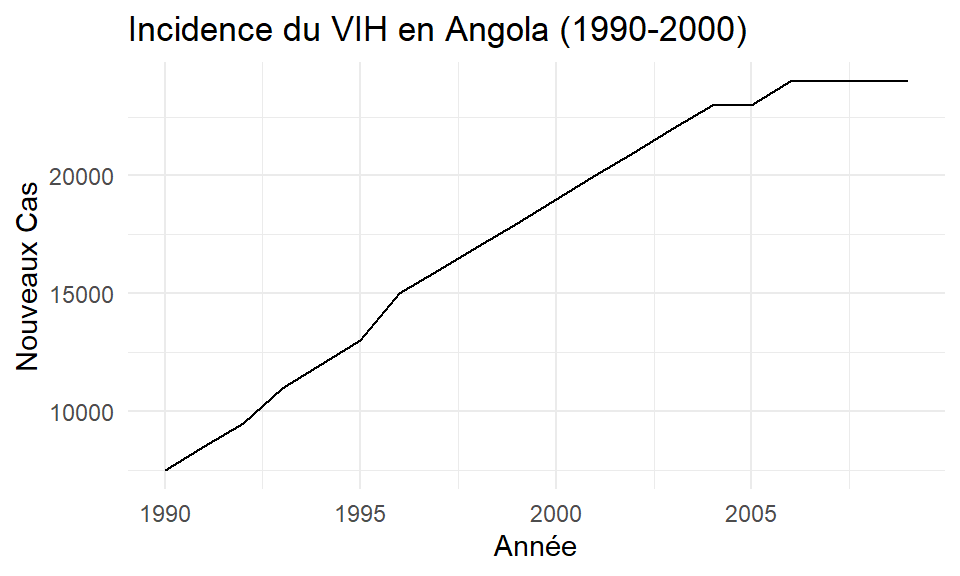

```r
generate_country_report <- function(data, country_name) {

  # Tracer les données
  country_data_plot <- subset(data, country == country_name)
  p <- ggplot(country_data_plot, aes(x = year, y = new_cases)) +
    geom_line() +
    theme_minimal() +
    labs(title = paste("Incidence du VIH en", country_name, "(1990-2000)"),
         x = "Année",
         y = "Nouveaux Cas")
  print(p)

  # Créer le tableau récapitulatif
  country_data_table <- data %>%
    filter(country == country_name) %>%
    group_by(year) %>%
    summarise(Total_Cases = sum(new_cases))

  # Identifier l'année la plus récente
  most_recent_year <- max(country_data_table$year)

  # Afficher le tableau en utilisant kable et mettre en évidence l'année la plus récente
  table_output <- country_data_table %>%
    gt() %>%
    tab_style(
      style = cell_fill(color = "lightblue"),
      locations = cells_body(
        columns = vars(year),
        rows = angola_summary$year == most_recent_year
      )
    ) %>%
    tab_header(title = "Résumé des cas de VIH en Angola par année")

  print(table_output)
}

# Exemple d'utilisation de la fonction
generate_country_report(hiv_data, "Angola")
```

Expliquons ce code :

1. **Déclaration de la fonction** : La fonction `generate_country_report()` prend deux paramètres : `data` (l’ensemble de données) et `country_name` (le nom du pays pour lequel le rapport doit être généré).

```r
generate_country_report <- function(data, country_name) {
  ......
}
```

2. **Tracé des Données** : La fonction commence par isoler les données pour le pays spécifié. Elle crée ensuite un graphique en ligne des nouveaux cas de VIH au fil des années en utilisant {ggplot}.

```r
# Tracé des données
  country_data_plot <- subset(data, country == country_name)
  p <- ggplot(country_data_plot, aes(x = year, y = new_cases)) +
    geom_line() +
    theme_minimal() +
    labs(title = paste("Incidence du VIH en", country_name, "(1990-2000)"),
         x = "Année",
         y = "Nouveaux Cas")
  print(p)
```

3. **Création de Tableau Récapitulatif** : Ensuite, elle filtre les données pour le pays spécifié, les regroupe par année et calcule le nombre total de nouveaux cas pour chaque année.

```r
 # Création du tableau récapitulatif
  country_data_table <- data %>%
    filter(country == country_name) %>%
    group_by(year) %>%
    summarise(Total_Cases = sum(new_cases))
```

4. **Mise en Évidence des Données Récentes** : La fonction identifie l’année la plus récente dans les données et la met en évidence dans le tableau récapitulatif.

```r
# Identifier l'année la plus récente
most_recent_year <- max(country_data_table$year)
```

```r
 # Afficher le tableau en utilisant kable et mettre en évidence l'année la plus récente
  table_output <- country_data_table %>%
    gt() %>%
    tab_style(
      style = cell_fill(color = "lightblue"),
      locations = cells_body(
        columns = vars(year),
        rows = angola_summary$year == most_recent_year
      )
    ) %>%
    tab_header(title = "Résumé des cas de VIH en Angola par année")
```

6. **Impression des Sorties** : Le graphique (`p`) et le tableau (`table_output`) sont imprimés dans la sortie.

```r
print(table_output)
```

- **Programmation Fonctionnelle Utilisant {purr}** :
  - Étend le processus de génération de rapports pour gérer plusieurs pays.
  - Utilise les paradigmes de programmation fonctionnelle en R, en particulier avec le package {purr}.
  - Facilite l’itération sur une liste de pays.
  - Applique la fonction `generate_country_report()` à chaque pays de la liste.
  - Rationalise le processus tout en respectant le principe DRY.

Cette approche basée sur les fonctions rend le code plus organisé et lisible et améliore également sa réutilisabilité et sa scalabilité, des aspects cruciaux des pratiques de programmation efficaces.

### 6.1.1 Utilisation de `map()`

- Vous avez une liste de pays pour lesquels des rapports doivent être générés.
- Utilisez la fonction `map()` du package {purrr} comme outil pour la tâche.
- La fonction `map()` permet d’appliquer la fonction `generate_country_report()` à chaque pays de la liste.
- Un exemple est fourni pour illustrer l’utilisation de `map()` en conjonction avec `generate_country_report()`.

```r
library(purrr)
# Vecteur de pays
countries <- c("Angola", "Nigeria", "Mali")

# En supposant que 'hiv_data' soit votre jeu de données
# Appliquer 'generate_country_report' à chaque pays
map(countries, ~generate_country_report(hiv_data, .))
```

[output not shown]

**Explication**

- `countries` est une liste de noms de pays pour la génération de rapports.
- `map()` applique `generate_country_report()` à chaque pays, en utilisant `~` pour créer une formule dans laquelle `.` est le pays actuel.
- Les rapports pour tous les pays de `countries` sont générés en appelant `generate_country_report(hiv_data, .)`.

# 7 Construction d’un Rapport Paramétrisé

## 7.1 Configuration de l’En-tête YAML

- **Définition des Paramètres** : Les paramètres sont définis dans l’en-tête YAML. C’est la section au début de votre fichier R Markdown où vous spécifiez divers paramètres pour votre document, tels que son titre, son format de sortie et ses paramètres.

## 7.2 Exemple avec un Jeu de Données sur le VIH

Considérez un fichier R Markdown conçu pour générer un rapport sur les données du VIH pour différents pays. Vous pouvez définir un paramètre dans l’en-tête YAML pour changer dynamiquement le pays pour lequel le rapport est généré.

YAML dans le fichier R Markdown :

```
---
title: "Rapport VIH par Pays"
output: html_document
params:
  country: "Angola"
---
```

**Explication**

1. **Titre du Document et Sortie** : Dans l’en-tête YAML, le document est intitulé “Rapport VIH par Pays”, et le format de sortie est spécifié comme un document HTML.
2. **Définition du Paramètre** :
   - `params` : Ce champ est utilisé pour définir des paramètres.
   - `country` : Sous `params`, un paramètre nommé `country` est déclaré. Ce paramètre contrôlera les données du pays utilisées dans le rapport.
   - `"Angola"` : La valeur par défaut pour le paramètre `country` est définie à “Angola”. Cela signifie que lorsque le rapport est généré sans spécifier un autre pays, il utilisera automatiquement les données pour l’Angola.

## 7.3 Utilisation du Paramètre dans le Document

Dans le document R Markdown, vous pouvez référencer ce paramètre en utilisant `params$country`. Par exemple, si vous avez une fonction comme `generate_country_report()`, vous pouvez l’appeler dans un bloc de code comme `generate_country_report(data, params$country)`. Cela utilisera la valeur du paramètre `country` pour déterminer les données du pays sur lesquelles rapporter.

En utilisant des paramètres, votre document R Markdown devient plus adaptable. Si vous devez générer un rapport pour un autre pays, vous changez simplement la valeur du paramètre lors de la tricotage du document, plutôt que de modifier le code lui-même. Cela rend votre document plus efficace et polyvalent, en particulier lorsqu’il s’agit de rapports nécessitant des mises à jour fréquentes ou des modifications basées sur différents sous-ensembles de données.

## 7.4 Mise en Œuvre des Paramètres dans l’Analyse

**Exemple de fragment de code**

```r
filtered_data <- tb_data %>%
                  filter(country == params$country, year == params$year)
```

## 7.5 Explication de la Cartographie des Paramètres

- **Accès aux Paramètres** : Les paramètres définis dans l’en-tête YAML de votre document R Markdown peuvent être accessibles dans le code en utilisant `params$nom_du_paramètre`. Cela est similaire à la manière dont vous accédez aux colonnes dans un dataframe en utilisant `dataframe$nom_de_la_colonne`.
- **Rapport Dynamique** : Lorsque vous créez des visualisations ou des résumés, vous utilisez `params$country` et `params$year` pour garantir que la sortie reflète le pays et l’année spécifiques définis en tant que paramètres. Cela signifie que le contenu du rapport s’adaptera en fonction des valeurs fournies pour ces paramètres au moment du tricotage du document.

Dans le contexte de R Markdown avec des paramètres, `params$nom_du_paramètre` accède à la valeur d’un paramètre nommé `nom_du_paramètre` qui a été défini dans l’en-tête YAML. Cela permet de générer des rapports dynamiques et interactifs basés sur ces valeurs de paramètres.

Dans l’ensemble, l’opérateur `$` est une partie clé de la syntaxe R qui facilite la manipulation des éléments dans les objets R.

## 7.6 Tricotage avec Différents Paramètres

- **Tricotage depuis RStudio :** Expliquez comment tricoter le document avec différentes valeurs de paramètres directement à partir du bouton de tricotage de RStudio, où vous pouvez spécifier les valeurs des paramètres dans une boîte de dialogue.
- **Tricotage en Ligne de Commande :** Pour une génération de rapport automatisée, vous pouvez utiliser des commandes R pour tricoter le document avec différents paramètres. Cela est particulièrement utile pour le traitement par lots ou la génération de rapport automatisée.
- Exemple de commande :

```r
rmarkdown::render("TB_Report.Rmd", params = list(country = "Angola"))
```

## 7.7 Tricotage avec Différents Paramètres

La création de rapports dynamiques et flexibles dans R Markdown implique souvent de tricoter le document avec des paramètres variables. Il existe deux principales manières de le faire : directement via l’interface de RStudio et via la ligne de commande pour l’automatisation.

### 7.7.1 Tricotage depuis RStudio

- **Utilisation du Bouton de Tricotage de RStudio** : Lorsque vous tricotez un document R Markdown dans RStudio qui contient des paramètres, une boîte de dialogue apparaîtra. Cette boîte de dialogue vous permet de spécifier les valeurs pour chaque paramètre avant de tricoter.
- **Sélection Interactive des Paramètres** : Cette méthode est conviviale et interactive, idéale pour la génération de rapport ad hoc où vous pouvez manuellement entrer ou modifier les valeurs des paramètres chaque fois que vous tricotez le document.
- **Personnalisation des Paramètres** : Dans la boîte de dialogue, vous pouvez personnaliser les paramètres selon vos besoins. Par exemple, si vous avez un paramètre pour le pays, vous pouvez changer sa valeur pour générer un rapport pour un autre pays.

### 7.7.2 Tricotage en Ligne de Commande

- **Génération de Rapport Automatisée** : Pour des scénarios où vous devez automatiser le processus de génération de rapport, comme dans le traitement par lots ou les rapports planifiés, vous pouvez tricoter des documents en utilisant des commandes R.
- **Exemple de Commande** :

```r
rmarkdown::render("hiv_incidence.Rmd", params = list(country = "Angola"))
```

Cette commande utilise la fonction `render` du package `rmarkdown`. Elle spécifie le fichier à rendre (`"hiv_incidence.Rmd"`) et définit l’argument `params` à une liste de valeurs de paramètres souhaitées. Dans cet exemple, le paramètre pays est défini sur “Angola”.

- **Flexibilité et Scripting** : Le tricotage en ligne de commande offre plus de flexibilité et peut être intégré dans des scripts pour des flux de travail automatisés. Cela est particulièrement utile lorsqu’on travaille avec de grands ensembles de données ou qu’on doit générer plusieurs rapports périodiquement.

Les deux méthodes offrent les moyens d’exploiter la puissance des rapports paramétrés dans R Markdown, répondant à différents besoins — de la génération de rapport interactive et pilotée par l’utilisateur à des processus automatisés et dirigés par des scripts. Cette flexibilité est l’une des forces clés de l’utilisation de R Markdown pour l’analyse de données et la création de rapports.

# 8 Le Processus Complet

Créer un rapport paramétré en R implique plusieurs étapes clés, de la configuration de votre projet R à l’automatisation du processus de génération de rapport. Passons en revue ces étapes en détail :

## 8.1 Étape 0 : Créer un Projet R

- **Fichier .Rproj** : Commencez par créer un projet R avec un fichier `.Rproj`. Ce fichier aide à gérer les chemins et les paramètres, rendant plus facile de travailler avec des fichiers et des données dans le projet.

## 8.2 Étape 1 : En-tête YAML

Voici un exemple d’en-tête YAML pour votre document R Markdown :

```r
---
title: "Rapport - `r stringr::str_to_title(params$state)`"
date: "`r format(Sys.time(), '%d %B %Y')`"
output: html_document
editor_options:
  chunk_output_type: console
params:
  state: "Alabama"
---
```

Cet en-tête configure le titre du document, la date, le format de sortie et définit un paramètre `state` avec une valeur par défaut de “Alabama”.

## 8.3 Étape 2 : Configuration de l’Environnement du Document

Dans le premier bloc de code, configurez votre environnement en chargeant les packages requis et votre jeu de données :

```r
# Configuration des options globales
knitr::opts_chunk$set(warning = FALSE, message = FALSE, echo = FALSE)

# Chargement des packages
pacman::p_load(ggplot2, dplyr, knitr, kableExtra)

# Chargement du jeu de données
hiv_data <- read.csv("hiv_incidence.csv")
```